# analysis

pc2853

November 23, 2018

This analysis is based on the final data set “finaldat.RData” and its subset data corresponding to 2 neighborhoods “subset_dat.RData”. These two datasets are built by running the code from “Data_prep.Rmd” and “Data_merge.Rmd” by Dew. The default significance level is 0.05.

```r
load('data/finaldat.RData')


load('data/subset_dat.RData')
```

1. hour of the day vs log response time —- ANOVA MODEL

```r
fit_1 = lm(log_response_time~hour_of_day, data = finaldat)
summary(fit_1)
```

```
##
## Call:
## lm(formula = log_response_time ~ hour_of_day, data = finaldat)
##
## Residuals:
##     Min      1Q  Median      3Q     Max
## -4.2071 -0.2222 -0.0061  0.2086  3.5128
##
## Coefficients:
##                     Estimate Std. Error t value Pr(>|t|)
## (Intercept)         1.499008   0.001976 758.505   <2e-16 ***
## hour_of_daydawn     0.117748   0.003508  33.569   <2e-16 ***
## hour_of_daymorning  0.024849   0.002756   9.016   <2e-16 ***
## hour_of_daynight   -0.036721   0.002785 -13.184   <2e-16 ***
## ---
## Signif. codes:  0 '***' 0.001 '**' 0.01 '*' 0.05 '.' 0.1 ' ' 1
##
## Residual standard error: 0.4302 on 167586 degrees of freedom
## Multiple R-squared:  0.01196,    Adjusted R-squared:  0.01195
## F-statistic: 676.4 on 3 and 167586 DF,  p-value: < 2.2e-16
```

```r
kable(anova(fit_1))
```

|  | Df | Sum Sq | Mean Sq | F value | Pr(>F) |
| --- | --- | --- | --- | --- | --- |
| hour_of_day | 3 | 375.5249 | 125.1749665 | 676.3858 | 0 |
| Residuals | 167586 | 31014.2124 | 0.1850645 | NA | NA |

Ho: different hour of the day makes no difference in logs response time. p-value: very small. conclusion: There is a difference of log response time in different time/hour of the day.

2. snow & prcp vs log response time —– linear regression

```r
fit_2 = lm(log_response_time~snow, data = finaldat)
fit_2 %>%
  broom::tidy() %>%
  knitr::kable(digits = 3)
```

| term | estimate | std.error | statistic | p.value |
| --- | --- | --- | --- | --- |
| (Intercept) | 1.510 | 0.001 | 1418.510 | 0 |
| snow | 0.001 | 0.000 | 9.625 | 0 |

```r
fit_2_2 = lm(log_response_time~prcp, data = finaldat)
fit_2_2 %>%
  broom::tidy() %>%
  knitr::kable(digits = 3)
```

| term | estimate | std.error | statistic | p.value |
| --- | --- | --- | --- | --- |
| (Intercept) | 1.509 | 0.001 | 1352.542 | 0 |
| prcp | 0.001 | 0.000 | 6.077 | 0 |

H0: There is no correlation between snow and log_response_time p-value: very small estimate: positive conclusion: There is a positive correlation between snow and log response time.

3. seasons vs log response time —– ANOVA

```r
fit_3 = lm(log_response_time~season, data = finaldat)
kable(anova(fit_3))
```

|  | Df | Sum Sq | Mean Sq | F value | Pr(>F) |
| --- | --- | --- | --- | --- | --- |
| season | 3 | 16.89714 | 5.6323801 | 30.08679 | 0 |
| Residuals | 167586 | 31372.84012 | 0.1872044 | NA | NA |

Ho: different seasons make no difference in logs response time. p-value: very small. conclusion: There is a difference of log response time in different seasons.

4. MLR based on snow, prcp, tmax, tmin(factors of nature environment) in different hour of the day—– MLR model

```r
fit_4 = lm(log_response_time~snow + prcp + tmax + tmin, data = finaldat)
fit_4 %>%
  broom::tidy() %>%
  knitr::kable(digits = 3)
```

| term | estimate | std.error | statistic | p.value |
| --- | --- | --- | --- | --- |
| (Intercept) | 1.528 | 0.003 | 473.242 | 0.000 |
| snow | 0.000 | 0.000 | 5.592 | 0.000 |
| prcp | 0.001 | 0.000 | 4.158 | 0.000 |
| tmax | -0.001 | 0.000 | -1.561 | 0.119 |
| tmin | -0.001 | 0.000 | -2.140 | 0.032 |

```r
fit_4_2 = finaldat %>%
  group_by(hour_of_day) %>%
  nest() %>%
  mutate(models = map(data, ~lm(log_response_time ~ snow + prcp + tmax + tmin, data = .x)),
         models = map(models, broom::tidy)) %>%
  select(-data) %>%
  unnest()

summary(fit_4_2)
```

```
##  hour_of_day            term              estimate
##  Length:20          Length:20          Min.   :-0.0015873
##  Class :character   Class :character   1st Qu.:-0.0003609
##  Mode  :character   Mode  :character   Median : 0.0002850
##                                        Mean   : 0.3083202
##                                        3rd Qu.: 0.0006247
##                                        Max.   : 1.6384811
##    std.error           statistic           p.value
##  Min.   :0.0001189   Min.   : -2.0099   Min.   :0.0000000
##  1st Qu.:0.0002415   1st Qu.: -0.7696   1st Qu.:0.0000416
##  Median :0.0007174   Median :  1.1729   Median :0.0466397
##  Mean   :0.0016733   Mean   : 48.7231   Mean   :0.2264709
##  3rd Qu.:0.0008887   3rd Qu.:  4.1682   3rd Qu.:0.3249007
##  Max.   :0.0073859   Max.   :250.7939   Max.   :0.9956099
```

```r
fit_4_2 %>%
  select(hour_of_day, term, estimate) %>%
  mutate(term = fct_inorder(term)) %>%
  spread(key = term, value = estimate) %>%
  knitr::kable(digits = 3)
```

| hour_of_day | (Intercept) | snow | prcp | tmax | tmin |
| --- | --- | --- | --- | --- | --- |
| afternoon | 1.513 | 0.000 | 0.001 | 0.000 | -0.002 |
| dawn | 1.638 | 0.000 | 0.000 | -0.001 | -0.001 |
| morning | 1.541 | 0.001 | 0.000 | -0.001 | 0.000 |
| night | 1.477 | 0.001 | 0.001 | 0.000 | -0.001 |

Despite there are correlations, the estimates are really small.

## Logistic regression with binary outcome 5min- / 5min+

```r
## Added snow and prcp categories
finaldat_ctg =
  finaldat %>%
  mutate(over_5min = if_else((over_5min == "5min-"), 0, 1),
         prcp_ctg =
           if_else(prcp == 0, "no_prcp",
           if_else((prcp > 0 & prcp <= 25), "low", "high")),
         snow_ctg =
           if_else(snow == 0, "no_snow",
           if_else((snow > 0 & snow <= 50), "low", "high")),
         prcp_ctg = fct_relevel(prcp_ctg, "no_prcp"),
         snow_ctg = fct_relevel(snow_ctg, "no_snow"),
         season = fct_relevel(season, "Spring"),
         hour_of_day = fct_relevel(hour_of_day, "morning"))

fit_logistic =
  glm(over_5min ~ season + hour_of_day + snow_ctg + prcp_ctg,
      family = binomial(), data = finaldat_ctg)

summary(fit_logistic)
```

```
##
## Call:
## glm(formula = over_5min ~ season + hour_of_day + snow_ctg + prcp_ctg,
##     family = binomial(), data = finaldat_ctg)
##
## Deviance Residuals:
##     Min       1Q   Median       3Q      Max
## -1.3482  -0.9731  -0.8659   1.3686   1.5532
##
## Coefficients:
##                       Estimate Std. Error z value Pr(>|z|)
## (Intercept)          -0.452668   0.013352 -33.902  < 2e-16 ***
## seasonFall            0.013660   0.014505   0.942 0.346327
## seasonSummer         -0.049039   0.014324  -3.424 0.000618 ***
## seasonWinter          0.065157   0.014835   4.392 1.12e-05 ***
## hour_of_dayafternoon -0.163036   0.013270 -12.286  < 2e-16 ***
## hour_of_daydawn       0.398682   0.016299  24.461  < 2e-16 ***
## hour_of_daynight     -0.348886   0.013443 -25.954  < 2e-16 ***
## snow_ctghigh          0.353960   0.047538   7.446 9.63e-14 ***
## snow_ctglow           0.163011   0.041675   3.911 9.17e-05 ***
## prcp_ctghigh          0.027821   0.028813   0.966 0.334269
## prcp_ctglow           0.003305   0.011605   0.285 0.775819
## ---
## Signif. codes:  0 '***' 0.001 '**' 0.01 '*' 0.05 '.' 0.1 ' ' 1
##
## (Dispersion parameter for binomial family taken to be 1)
##
##     Null deviance: 221171  on 167589  degrees of freedom
## Residual deviance: 218840  on 167579  degrees of freedom
## AIC: 218862
##
## Number of Fisher Scoring iterations: 4
```

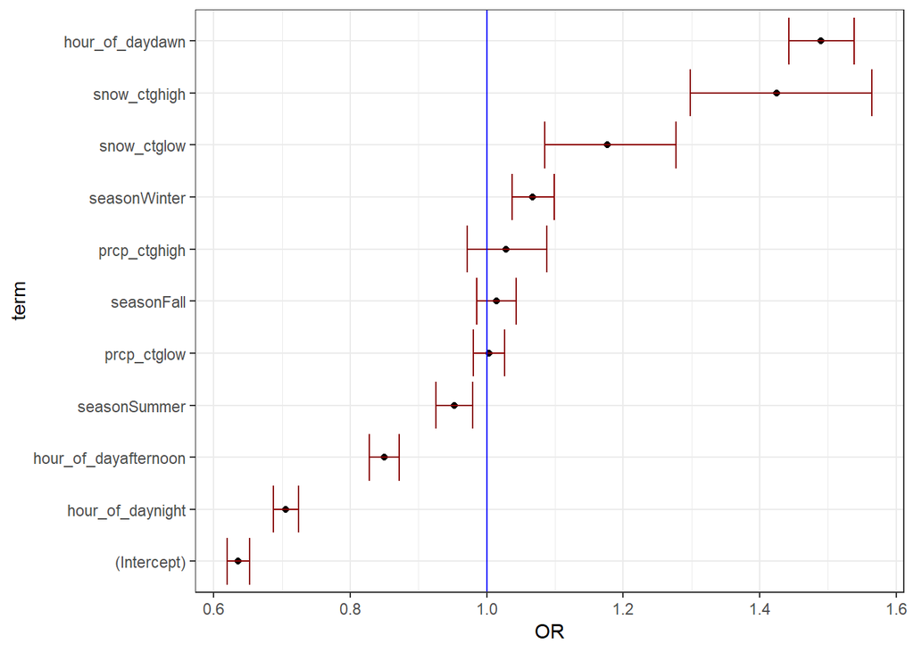

```r
fit_logistic %>%
  broom::tidy() %>%
  mutate(OR = exp(estimate),
         lower_CI_OR = exp(estimate - 1.96*std.error),
         upper_CI_OR = exp(estimate + 1.96*std.error)) %>%
  select(term, OR, lower_CI_OR, upper_CI_OR) %>%
  mutate(term = fct_reorder(term, OR)) %>%
  ggplot(aes(x = term, y = OR)) +
  geom_point() +
  geom_errorbar(aes(ymin = lower_CI_OR, ymax = upper_CI_OR),
                color = "darkred") +
  coord_flip() +
  geom_hline(yintercept = 1.0, color = "blue") +
  theme_bw()
```

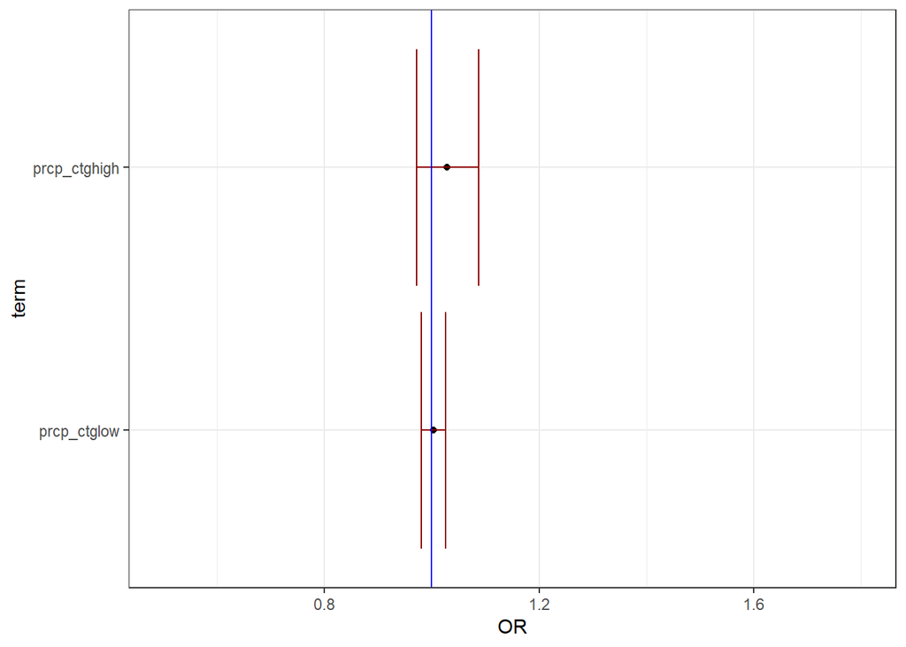

```r
## prcp_ctg
fit_logistic %>%
  broom::tidy() %>%
  filter(str_detect(term, "prcp_ctg")) %>%
  mutate(OR = exp(estimate),
         lower_CI_OR = exp(estimate - 1.96*std.error),
         upper_CI_OR = exp(estimate + 1.96*std.error)) %>%
  select(term, OR, lower_CI_OR, upper_CI_OR) %>%
  mutate(term = fct_reorder(term, OR)) %>%
  ggplot(aes(x = term, y = OR)) +
  geom_point() +
  geom_errorbar(aes(ymin = lower_CI_OR, ymax = upper_CI_OR),
                color = "darkred") +
  scale_y_continuous(limits = c(0.5, 1.8)) +
  coord_flip() +
  geom_hline(yintercept = 1.0, color = "blue") +
  theme_bw()
```

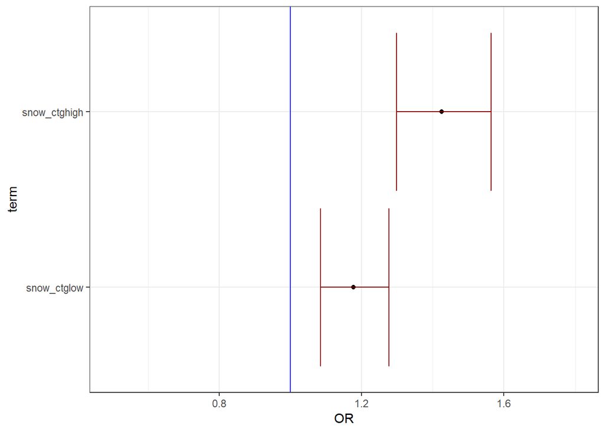

```r
## snow_ctg
fit_logistic %>%
  broom::tidy() %>%
  filter(str_detect(term, "snow_ctg")) %>%
  mutate(OR = exp(estimate),
         lower_CI_OR = exp(estimate - 1.96*std.error),
         upper_CI_OR = exp(estimate + 1.96*std.error)) %>%
  select(term, OR, lower_CI_OR, upper_CI_OR) %>%
  mutate(term = fct_reorder(term, OR)) %>%
  ggplot(aes(x = term, y = OR)) +
  geom_point() +
  geom_errorbar(aes(ymin = lower_CI_OR, ymax = upper_CI_OR),
                color = "darkred") +
  scale_y_continuous(limits = c(0.5, 1.8)) +
  coord_flip() +
  geom_hline(yintercept = 1.0, color = "blue") +
  theme_bw()
```

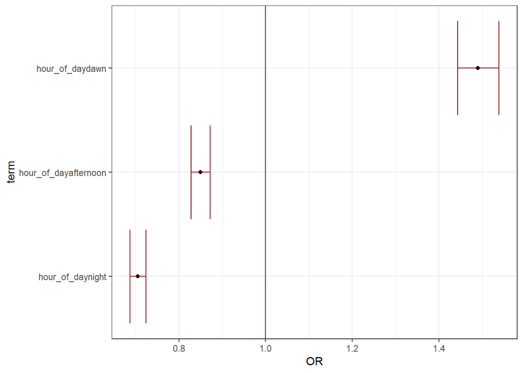

```r
## Hour of day
fit_logistic %>%
  broom::tidy() %>%
  filter(str_detect(term, "hour_of_day")) %>%
  mutate(OR = exp(estimate),
         lower_CI_OR = exp(estimate - 1.96*std.error),
         upper_CI_OR = exp(estimate + 1.96*std.error)) %>%
  select(term, OR, lower_CI_OR, upper_CI_OR) %>%
  mutate(term = fct_reorder(term, OR)) %>%
  ggplot(aes(x = term, y = OR)) +
  geom_point() +
  geom_errorbar(aes(ymin = lower_CI_OR, ymax = upper_CI_OR),
                color = "darkred") +
  coord_flip() +
  geom_hline(yintercept = 1.0, color = "blue") +
  theme_bw()
```

## (1) Mean response time in snowy condition

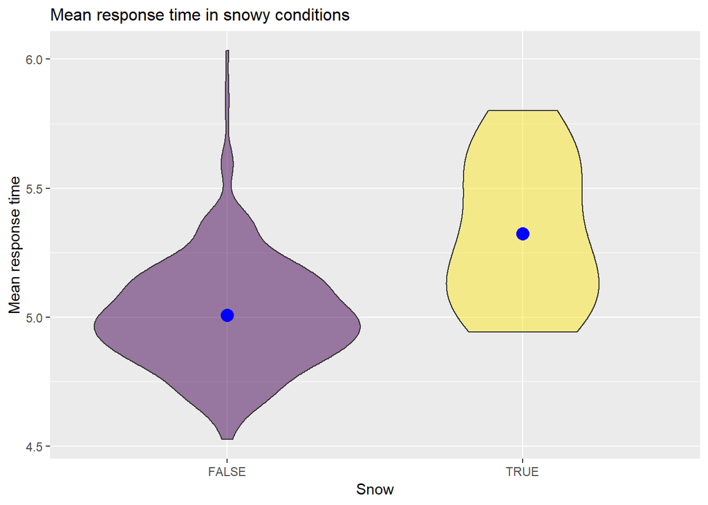

```r
## OR result above matches with the results below
finaldat %>%
  mutate(snow = snow > 0) %>%
  group_by(date, snow) %>%
  summarise(mean_resp_time = mean(response_time)) %>%
  ggplot(aes(x = snow, y = mean_resp_time)) +
  geom_violin(aes(fill = factor(snow)), alpha = .5) +
  stat_summary(fun.y = mean, geom = "point", size = 4, color = "blue") +
  labs(
    title = "Mean response time in snowy conditions",
    y = "Mean response time",
    x = "Snow"
  ) +
  viridis::scale_fill_viridis(
    name = "Snow",
    discrete = TRUE) +
  theme(plot.title = element_text(size = 12),
        strip.background = element_rect(fill = "black"),
        strip.text = element_text(color = "white", face = "bold"),
        legend.position = "None")
```

## (2) Response time (smoothed line) by hour of the day

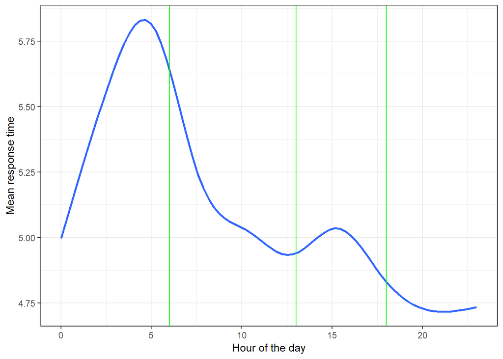

```r
finaldat %>%
    group_by(hour) %>%
  ggplot(aes(x = hour, y = response_time)) +
  geom_smooth(se = FALSE) +
  labs(x = "Hour of the day", y = "Mean response time") +
  geom_vline(xintercept = c(6, 13, 18), color = "green") +
  theme_bw()
```

## Logistic regression with binary outcome 8min- / 8min+

```r
finaldat_8min =
  finaldat %>%
  mutate(over_8min = ifelse(response_time > 8, "8min+", "8min-"))
## Added snow and prcp categories
finaldat_ctg_8min =
  finaldat_8min %>%
  mutate(over_8min = if_else((over_8min == "8min-"), 0, 1),
         prcp_ctg =
           if_else(prcp == 0, "no_prcp",
           if_else((prcp > 0 & prcp <= 25), "low", "high")),
         snow_ctg =
           if_else(snow == 0, "no_snow",
           if_else((snow > 0 & snow <= 50), "low", "high")),
         prcp_ctg = fct_relevel(prcp_ctg, "no_prcp"),
         snow_ctg = fct_relevel(snow_ctg, "no_snow"),
         season = fct_relevel(season, "Spring"),
         hour_of_day = fct_relevel(hour_of_day, "morning"))

fit_logistic_8min =
  glm(over_8min ~ season + hour_of_day + snow_ctg + prcp_ctg,
      family = binomial(), data = finaldat_ctg_8min)

summary(fit_logistic_8min)
```

```
##
## Call:
## glm(formula = over_8min ~ season + hour_of_day + snow_ctg + prcp_ctg,
##     family = binomial(), data = finaldat_ctg_8min)
##
## Deviance Residuals:
##     Min       1Q   Median       3Q      Max
## -0.4579  -0.3740  -0.3654  -0.3271   2.4710
##
## Coefficients:
##                       Estimate Std. Error z value Pr(>|z|)
## (Intercept)          -2.636763   0.026376 -99.969  < 2e-16 ***
## seasonFall            0.058315   0.028900   2.018  0.04361 *
## seasonSummer         -0.002037   0.028837  -0.071  0.94369
## seasonWinter          0.070582   0.029485   2.394  0.01668 *
## hour_of_dayafternoon -0.034560   0.025506  -1.355  0.17542
## hour_of_daydawn      -0.092216   0.032849  -2.807  0.00500 **
## hour_of_daynight     -0.322687   0.027261 -11.837  < 2e-16 ***
## snow_ctghigh          0.387805   0.084316   4.599 4.24e-06 ***
## snow_ctglow           0.212945   0.077437   2.750  0.00596 **
## prcp_ctghigh         -0.043112   0.057985  -0.744  0.45717
## prcp_ctglow          -0.024123   0.023208  -1.039  0.29860
## ---
## Signif. codes:  0 '***' 0.001 '**' 0.01 '*' 0.05 '.' 0.1 ' ' 1
##
## (Dispersion parameter for binomial family taken to be 1)
##
##     Null deviance: 78187  on 167589  degrees of freedom
## Residual deviance: 77978  on 167579  degrees of freedom
## AIC: 78000
##
## Number of Fisher Scoring iterations: 5
```

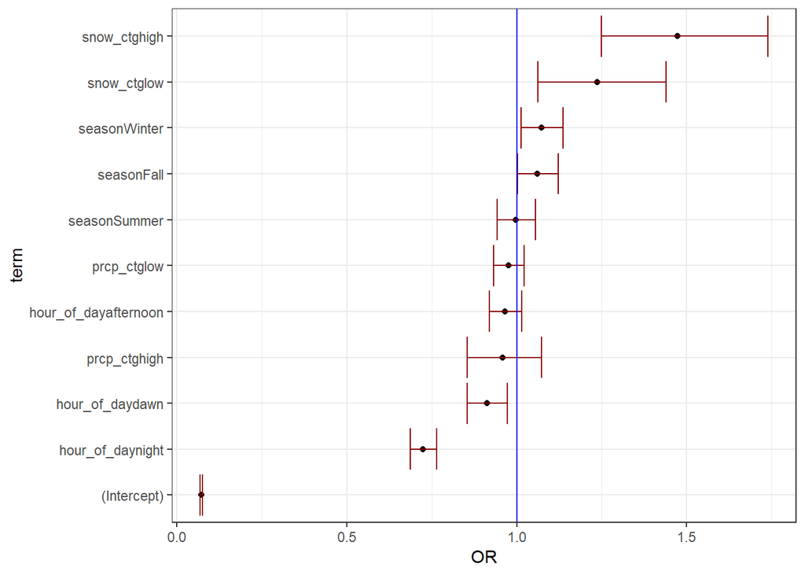

```r
fit_logistic_8min %>%
  broom::tidy() %>%
  mutate(OR = exp(estimate),
         lower_CI_OR = exp(estimate - 1.96*std.error),
         upper_CI_OR = exp(estimate + 1.96*std.error)) %>%
  select(term, OR, lower_CI_OR, upper_CI_OR) %>%
  mutate(term = fct_reorder(term, OR)) %>%
  ggplot(aes(x = term, y = OR)) +
  geom_point() +
  geom_errorbar(aes(ymin = lower_CI_OR, ymax = upper_CI_OR),
                color = "darkred") +
  coord_flip() +
  geom_hline(yintercept = 1.0, color = "blue") +
  theme_bw()
```

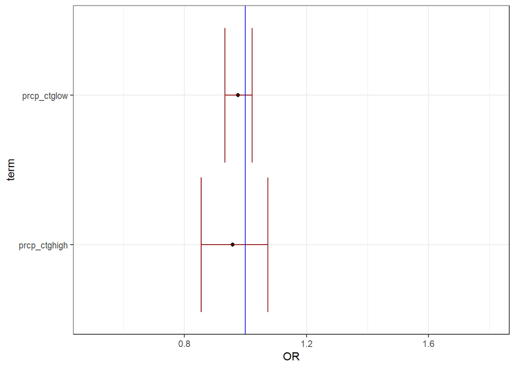

```r
## prcp_ctg
fit_logistic_8min %>%
  broom::tidy() %>%
  filter(str_detect(term, "prcp_ctg")) %>%
  mutate(OR = exp(estimate),
         lower_CI_OR = exp(estimate - 1.96*std.error),
         upper_CI_OR = exp(estimate + 1.96*std.error)) %>%
  select(term, OR, lower_CI_OR, upper_CI_OR) %>%
  mutate(term = fct_reorder(term, OR)) %>%
  ggplot(aes(x = term, y = OR)) +
  geom_point() +
  geom_errorbar(aes(ymin = lower_CI_OR, ymax = upper_CI_OR),
                color = "darkred") +
  scale_y_continuous(limits = c(0.5, 1.8)) +
  coord_flip() +
  geom_hline(yintercept = 1.0, color = "blue") +
  theme_bw()
```

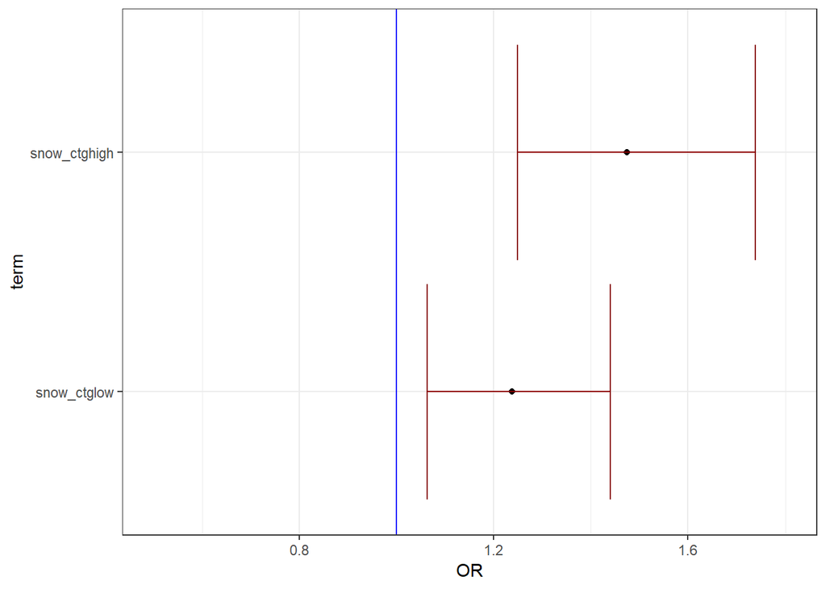

```r
## snow_ctg
fit_logistic_8min %>%
  broom::tidy() %>%
  filter(str_detect(term, "snow_ctg")) %>%
  mutate(OR = exp(estimate),
         lower_CI_OR = exp(estimate - 1.96*std.error),
         upper_CI_OR = exp(estimate + 1.96*std.error)) %>%
  select(term, OR, lower_CI_OR, upper_CI_OR) %>%
  mutate(term = fct_reorder(term, OR)) %>%
  ggplot(aes(x = term, y = OR)) +
  geom_point() +
  geom_errorbar(aes(ymin = lower_CI_OR, ymax = upper_CI_OR),
                color = "darkred") +
  scale_y_continuous(limits = c(0.5, 1.8)) +
  coord_flip() +
  geom_hline(yintercept = 1.0, color = "blue") +
  theme_bw()
```

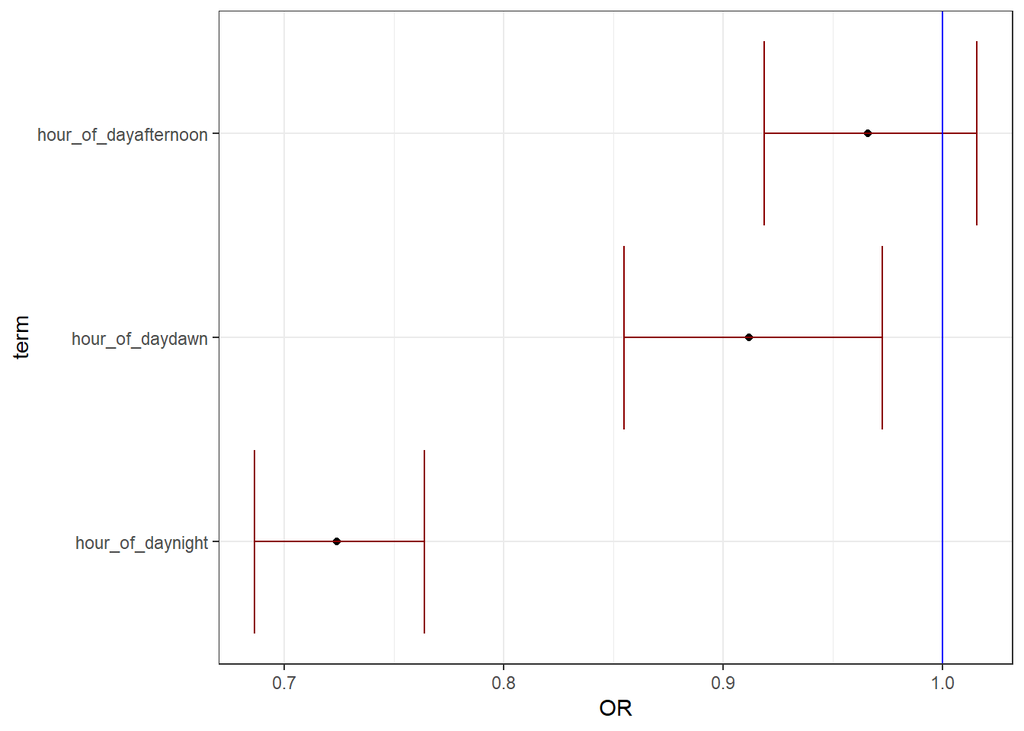

```r
## Hour of day
fit_logistic_8min %>%
  broom::tidy() %>%
  filter(str_detect(term, "hour_of_day")) %>%
  mutate(OR = exp(estimate),
         lower_CI_OR = exp(estimate - 1.96*std.error),
         upper_CI_OR = exp(estimate + 1.96*std.error)) %>%
  select(term, OR, lower_CI_OR, upper_CI_OR) %>%
  mutate(term = fct_reorder(term, OR)) %>%
  ggplot(aes(x = term, y = OR)) +
  geom_point() +
  geom_errorbar(aes(ymin = lower_CI_OR, ymax = upper_CI_OR),
                color = "darkred") +
  coord_flip() +
  geom_hline(yintercept = 1.0, color = "blue") +
  theme_bw()
```

### estimate the effect of Street closure on response time in the selected two neighborhoods.

5. street closure(binary data 0 or 1) vs log response time —— t-test

```r
t.test(log_response_time~street_closed, data = dat_subset) %>%
  broom::tidy() %>%
  select(estimate, p.value, conf.low, conf.high, method, alternative) %>%
  knitr::kable(digits = 3)
```

| estimate | p.value | conf.low | conf.high | method | alternative |
| --- | --- | --- | --- | --- | --- |
| -0.031 | 0.036 | -0.059 | -0.002 | Welch Two Sample t-test | two.sided |

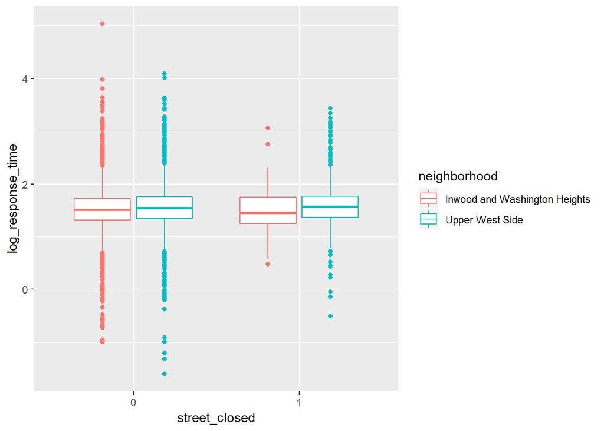

```r
#just curious about the visualization
dat_subset %>%
  mutate(street_closed = as.factor(street_closed)) %>%
  ggplot(aes(x = street_closed, y = log_response_time, color = neighborhood)) +
  geom_boxplot()
```

```r
#actually the difference is really small.
```

H0: The presence of street closure affects log response time. p value: 0.036 < 0.05 conclusion: Having street closure while incident happens affects the log response time.